# Learning Analytics for a FutureLearn MOOC

ALICE TING

2026-01-05

The full reproducible project, code, and data processing scripts are available at: https://github.com/AliceTing12/AnalyticsFinal_Project

# Introduction

Learning analytics aims to use data generated by learners to better understand patterns of engagement and support learning outcomes. In large-scale online courses, traditional measures such as attendance are not available, making platform interaction data a key source of insight.This project analyses data from multiple runs of a FutureLearn MOOC on cyber security. The analysis focuses on the relationship between learner engagement and course completion, and follows the CRISP-DM framework through two consecutive analytical cycles.

# CRISP-DM Cycle 1

## Business Understanding

The primary stakeholders in this analysis are FutureLearn course designers, instructors, and learning analytics teams. These stakeholders are interested in understanding how learners engage with course content and which behaviours are associated with successful course completion. In large-scale online courses, high enrolment but low completion is common, making it difficult to identify learners who may be at risk of disengagement.

The aim of this investigation is to examine whether patterns of learner engagement, measured through platform activity data, are associated with course completion. This analysis seeks to support stakeholders in making evidence-based decisions about course design and learner support strategies. Success for this project is defined by identifying clear and interpretable relationships between learner activity and course completion, and by demonstrating whether these relationships remain consistent across two CRISP-DM analytical cycles.

## Data Understanding

The dataset consists of raw CSV files exported from the FutureLearn platform for seven runs of a cyber security MOOC. Each run contains multiple data tables capturing enrolment information, learner activity, and survey responses. An initial inventory of the raw files showed that not all table types were consistently available across runs.To ensure comparability, this analysis focused on enrolment and step activity data, which were present for all course runs and directly related to learner engagement.

After data preparation, the core analytical dataset contained 37,296 learner records and 17 variables. Each row represents a learner enrolment in a specific course run. The dataset includes learner identifiers, enrolment and participation timestamps, demographic descriptors, and a derived engagement measure.

Key variables used in this analysis include:

- `learner_id` – unique learner identifier
- `run` – course run number
- `fully_participated_at` – used to derive course completion
- `total_activity` – total recorded activity events per learner
- `completed` – logical variable indicating course completion

The dataset contains a mixture of character variables (e.g., timestamps and demographics), integer variables (activity counts), and logical variables (completion status).

Initial inspection revealed substantial missing values in demographic fields and a large number of learners with zero recorded activity. These data quality characteristics informed both the selection of variables and the refinement of the second analysis cycle.

## Data Preparation

To prepare the data for analysis, enrolment records from all course runs were combined into a single dataset, with each learner linked to a specific run. Activity log files were then aggregated at the learner level to produce a simple measure of engagement based on the total number of recorded activity events. These engagement summaries were joined to enrolment data using learner identifiers, resulting in a single learner-level dataset suitable for exploratory analysis.

## Exploratory Analysis

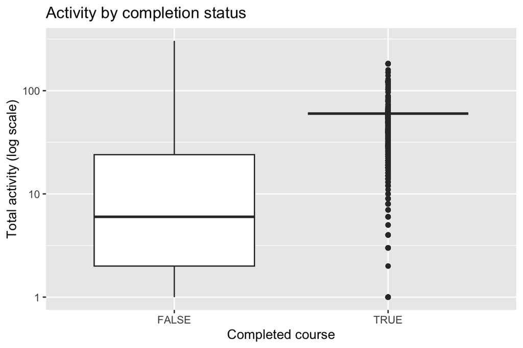

This figure compares total recorded activity between learners who completed the course and those who did not. Activity levels are highly skewed, so a logarithmic scale is used to allow meaningful comparison across learners with very different engagement levels. Learners who completed the course generally show substantially higher levels of activity than those who did not complete. Non-completing learners are concentrated at very low activity levels, while completing learners tend to exhibit consistently higher engagement. This suggests a strong association between sustained engagement and course completion.

## Evaluation

The results from the first analysis cycle indicate a clear relationship between learner activity and course completion. However, this analysis is exploratory and does not establish causality. Completion was approximated using available participation indicators, which may not fully capture learning outcomes. In addition, activity measures reflect platform interaction rather than learning quality.The success criteria were met, as clear and interpretable differences in engagement between completing and non-completing learners were observed.

## Deployment

From a practical perspective, these findings suggest that early engagement data could be used to identify learners at risk of disengagement. Monitoring activity levels during the early stages of the course may enable timely interventions, such as reminder emails or additional support resources. Such approaches could help improve learner retention in future course runs.

# CRISP-DM Cycle 2

## Revised Business Understanding

Results from Cycle 1 showed that a large proportion of enrolled learners recorded little or no activity. This raised the concern that the observed relationship between engagement and completion might be driven primarily by inactive enrolments rather than meaningful differences among participating learners.

The second analysis cycle therefore focuses on learners who engaged with the course at least once. The refined objective is to examine whether the relationship between engagement and completion remains evident when only active learners are considered.

## Revised Data Preparation

For the second analysis cycle, learners with zero recorded activity were excluded from the dataset. This refinement ensured that the analysis focused on learners who engaged with at least some course content. No additional data sources were introduced, and the same engagement measures were retained.

## Exploratory Analysis (Refined)

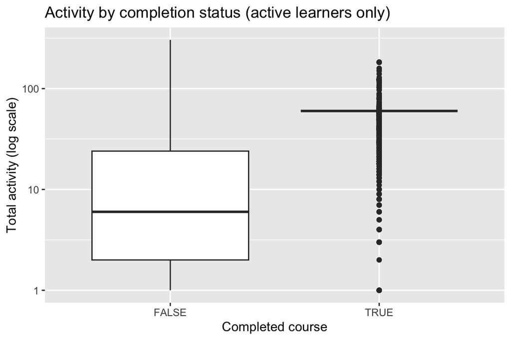

## Evaluation

The refined analysis supports the findings from Cycle 1 and strengthens confidence in the observed relationship between engagement and course completion. By focusing on active learners, the analysis reduces the influence of non-participating enrolments. However, the results remain descriptive and do not account for factors such as learner motivation, prior knowledge, or external constraints. As such, the findings should be interpreted as indicative rather than predictive.

# Discussion and Limitations

This analysis examined the relationship between learner engagement and course completion across multiple runs of a FutureLearn MOOC using two CRISP-DM cycles. Results from both cycles consistently showed that learners who completed the course tended to exhibit higher levels of recorded activity. Refining the analysis in Cycle 2 to focus on active learners confirmed that this relationship was not driven solely by inactive enrolments, strengthening confidence in the findings. However, the analysis relies on platform interaction data, which measures quantity rather than quality of engagement. In addition, factors such as learner motivation, prior experience, and external commitments were not available and may influence both engagement and completion.

# Conclusion

This project applied the CRISP-DM framework to explore learner engagement and course completion in a large-scale online course. Across two analytical cycles, higher levels of learner activity were consistently associated with course completion. Refining the analysis to exclude inactive learners demonstrated that this relationship was robust and not solely driven by non-participating enrolments. While the findings are descriptive rather than predictive, they highlight the potential value of engagement data for identifying learners at risk of disengagement. Future work could extend this analysis by examining temporal patterns of activity or incorporating additional learner characteristics to support more targeted learning analytics interventions.